# Intro to Data Science - HW 6

##### Copyright Jeffrey Stanton, Jeffrey Saltz, and Jasmina Tacheva

```r
# Enter your name here: Shaun McKellar Jr
```

### Attribution statement: (choose only one and delete the rest)

```r
# 1. I did this homework by myself, with help from the book and the professor.
# 3. I did this homework with help from Angela Ozelski but did not cut and paste any code.
```

```r
library(dbplyr)
library(tidyverse)
```

```r
library("ggplot2")
library(readxl)
library(tinytex)
library(jsonlite)
library("rjson")
library(maps)
library("ggmap")
library("mapproj")
library(tinytex)
```

Last assignment we explored **data visualization** in R using the **ggplot2** package. This homework continues to use ggplot, but this time, with maps. In addition, we will merge datasets using the built-in **merge( )** function, which provides a similar capability to a **JOIN in SQL** (don’t worry if you do not know SQL). Many analytical strategies require joining data from different sources based on a **“key”** – a field that two datasets have in common.

## Step 1: Load the population data

1. Read the following JSON file, https://intro-datascience.s3.us-east-2.amazonaws.com/cities.json and store it in a variable called **pop**.

Examine the resulting pop dataframe and add comments explaining what each column contains.

```r
pop <- jsonlite::fromJSON("https://intro-datascience.s3.us-east-2.amazonaws.com/cities.json")
```

```r
#Lists the growth from 2000-13
#The rank based on population
#The state and city
#The lat and long
```

2. Calculate the **average population** in the dataframe. Why is using mean() directly not working? Find a way to correct the data type of this variable so you can calculate the average (and then calculate the average)

Hint: use **str(pop)** or **glimpse(pop)** to help understand the dataframe

```r
#Needed to change the type to numeric
mean(as.numeric(pop$population))
```

```
## [1] 131132.4
```

```r
str(pop)
```

```
## 'data.frame':    1000 obs. of  7 variables:
##  $ city                    : chr  "New York" "Los Angeles" "Chicago" "Houston" ...
##  $ growth_from_2000_to_2013: chr  "4.8%" "4.8%" "-6.1%" "11.0%" ...
##  $ latitude                : num  40.7 34.1 41.9 29.8 40 ...
##  $ longitude               : num  -74 -118.2 -87.6 -95.4 -75.2 ...
##  $ population              : chr  "8405837" "3884307" "2718782" "2195914" ...
##  $ rank                    : chr  "1" "2" "3" "4" ...
##  $ state                   : chr  "New York" "California" "Illinois" "Texas" ...
```

3. What is the population of the smallest city in the dataframe? Which state is it in?

```r
#finds the index
which.min(pop$population)
```

```
## [1] 1000
```

```r
#Florida, Panama City 36877 people
pop[1000,]
```

```
##             city growth_from_2000_to_2013 latitude longitude population rank
## 1000 Panama City                     0.1% 30.15881 -85.66021      36877 1000
##        state
## 1000 Florida
```

## Step 2: Merge the population data with the state name data

4. Read in the state name .csv file from the URL below into a dataframe named **abbr** (for “abbreviation”) – make sure to use the read_csv() function from the tidyverse package:  
   https://intro-datascience.s3.us-east-2.amazonaws.com/statesInfo.csv

```r
read_csv(url('https://intro-datascience.s3.us-east-2.amazonaws.com/statesInfo.csv')) -> abbr
```

5. To successfully merge the dataframe **pop** with the **abbr** dataframe, we need to identify a **column they have in common** which will serve as the **“key”** to merge on. One column both dataframes have is the **state column**. The only problem is the slight column name discrepancy – in **pop**, the column is called **“state”** and in **abbr** – **“State.”** These names need to be reconciled for the merge() function to work. Find a way to rename **abbr’s “State”** to **match** the **state column in pop**.

```r
abbr <- abbr %>%
  rename(state = State)
```

6. Merge the two dataframes (using the **‘state’ column** from both dataframes), storing the resulting dataframe in **dfNew**.

```r
dfNew <- merge(abbr,pop, by = "state")
```

7. Review the structure of **dfNew** and explain the columns (aka attributes) in that dataframe.

```r
#Lists the growth from 2000-2013
#The rank based on population
#The state, city and abbreviation
#The lat and long
```

## Step 3: Visualize the data

8. Plot points (on top of a map of the US) for **each city**. Have the **color** represent the **population**.

[figure not shown]

```r
states <- map_data("state")
map.simple <- ggplot() +
  geom_polygon(data = states, color="black", fill="white",
               aes(x=long,y=lat,group=group)) + coord_map() +
  geom_point(data=dfNew,aes(x=longitude,y=latitude,color=population))

plot(map.simple)
```

1. Add a block comment that criticizes the resulting map. It’s not very good.

```r
#Seems very clustered and hard to tell what's going on in the graph
```

## Step 4: Group by State

10. Use group_by and summarise to make a dataframe of state-by-state population. Store the result in **dfSimple**.

```r
dfSimple <- dfNew %>%
  group_by(state) %>%
  summarize(population_state = sum(as.numeric(population)))
```

11. Name the most and least populous states in **dfSimple** and show the code you used to determine them.

```r
which.min(dfSimple$population_state)
```

```
## [1] 46
```

```r
#Vermont is the last populus state
dfSimple[46,1]
```

```
## # A tibble: 1 × 1
##   state
##   <chr>
## 1 Vermont
```

```r
which.max(dfSimple$population_state)
```

```
## [1] 5
```

```r
dfSimple[5,1]
```

```
## # A tibble: 1 × 1
##   state
##   <chr>
## 1 California
```

```r
#California is the most populus state
```

## Step 5: Create a map of the U.S., with the color of the state representing the state population

12. Make sure to expand the limits correctly and that you have used **coord_map** appropriately.

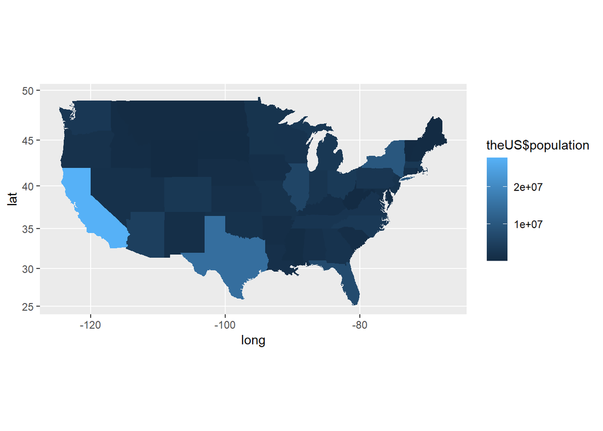

```r
dfSimple$region <- tolower(dfSimple$state)

theUS <- merge(states,dfSimple, region = region)

theUS %>% ggplot() + geom_polygon(aes( x= long, y= lat, group= group,, fill = theUS$population)) + coord_map()
```